# Random Forests For All

A Journey Through One Random Forest

Matt McGehee (Advisor: Dr. Seals)

October 20, 2024

## Data Exploration

The dataset contains sales transaction details from a B2B context. The data tracks information on sales orders, quantities ordered, shipping details, and item-level statuses. Below is the data definition table that explains the key attributes.

Sales Transaction Dataset Definition

| Attribute | Format | Description |
| --- | --- | --- |
| OPCO | Varchar | The customer placing the order, typically a distributor. |
| SalesOrderID | Numeric | Unique identifier assigned to each sales order. |
| CustomerPO | Numeric | Customer's identifier for their order, sent to BCC. |
| Product | Varchar | Unique identifier assigned to each product. |
| Description | Varchar | Description of the product being sold. |
| Substrate | Varchar | Type of product/material. |
| RequestedDeliveryDate | Date | Date the delivery was scheduled originally. |
| DateFulfilled | Date | Date the delivery was made. |
| qtyOrdered | Numeric | Quantity ordered on the order. |
| qtyFulfilled | Numeric | Quantity delivered on the order. |
| UnitPrice | Numeric | Price of each case of product SSI charges the customer. |
| TotalPrice | Numeric | Total price of the sales order. |
| Class | Varchar | Customer name. |
| ShipToName | Varchar | Name of the ordering party. |
| ShipToAddress | Varchar | Address where the order needs to be delivered. |
| SalesOrderStatus | Varchar | Status of sales order. |
| SalesItemStatus | Varchar | Status of each line item on the sales order. |

## Data Summary

This dataset allows for various analyses including:

- Order fulfillment performance: By comparing the qtyOrdered and qtyFulfilled attributes, and the RequestedDeliveryDate against the DateFulfilled, one can analyze how efficiently orders are being fulfilled and whether delivery deadlines are met.
- Sales trends and pricing: The UnitPrice and TotalPrice fields, alongside Product and Class, provide opportunities to evaluate product pricing strategies and customer buying patterns.
- Customer segmentation: With attributes like Class and ShipToName, you can analyze customer behavior and segment them based on order sizes, frequency, or geography.

This dataset provides a detailed overview of the company’s sales transactions. By leveraging these attributes, one can assess order performance, customer segmentation, and pricing strategies.

## Table 1

|  | Total Orders | Closed Short | Fulfilled |
| --- | --- | --- | --- |
|  | (n=7585) | (n=733) | (n=6852) |
| Top Customers |  |  |  |
| Smoothie Island | 1701 (22.43%) | 455 (62.07%) | 1246 (18.18%) |
| Philly Bite | 1556 (20.51%) | 267 (36.43%) | 1289 (18.81%) |
| PlatePioneers | 1396 (18.40%) | 143 (19.51%) | 1253 (18.29%) |
| Berl Company | 906 (11.94%) | 5 (0.68%) | 901 (13.15%) |
| DineLink Intl | 589 (7.77%) | 42 (5.73%) | 547 (7.98%) |
| Top Products |  |  |  |
| DC-01 | 1135 (14.96%) | 345 (47.07%) | 790 (11.53%) |
| TSC-PQB-01 | 1087 (14.33%) | 389 (53.07%) | 698 (10.19%) |
| TSC-PW14X16-01 | 848 (11.18%) | 283 (38.61%) | 565 (8.25%) |
| CMI-PCK-01 | 802 (10.57%) | 288 (39.29%) | 514 (7.50%) |
| PC-05-B1 | 745 (9.82%) | 220 (30.01%) | 525 (7.66%) |
| Top Distributors |  |  |  |
| Ed Don & Company - Miramar | 210 (2.77%) | 0 (0.00%) | 210 (3.06%) |
| PFG- Gainesville | 197 (2.60%) | 0 (0.00%) | 197 (2.88%) |
| Ed Don & Company - Woodridge | 186 (2.45%) | 0 (0.00%) | 186 (2.71%) |
| Ed Don & Company - Mira Loma | 180 (2.37%) | 0 (0.00%) | 180 (2.63%) |
| .Ed Don - Miramar | 162 (2.14%) | 0 (0.00%) | 162 (2.36%) |
| Top Substrates | Paper | Plastic | Bagasse |
| Revenue($103,826,286) | $54,838,585 (52.82%) | $40,336,669 (38.85%) | $4,350,337 (4.19%) |
| Quantity Ordered | Min | Mean | Max |
| Total Ordered(1,971,237) | 1 | 61.47 | 23,160 |
| Unit Price | Min | Mean | Max |
| Key Stats | $0.16 | $62.60 | $864.00 |
| Total Price | Min | Mean | Max |
| Key Stats | $4.92 | $3,430.74 | $143,084.74 |

## Data Visualizations

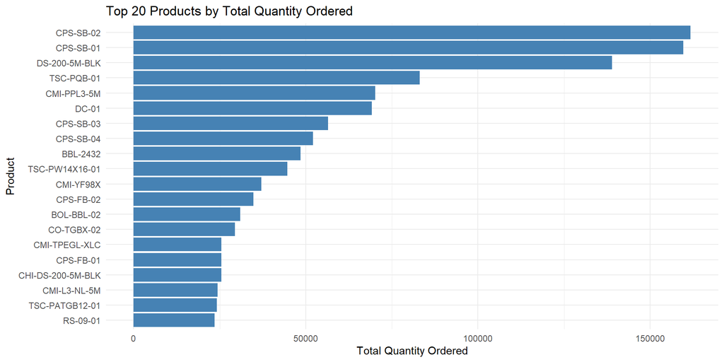

## Data Visualizations (cont)

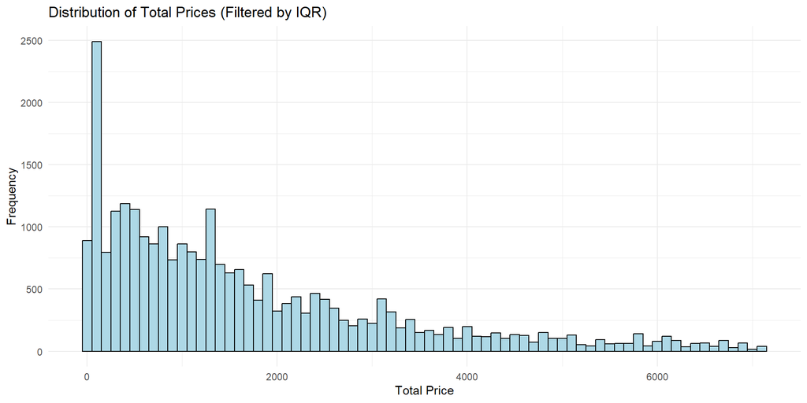

## Methodolgy - Random Forest Classification

- **Random Forest Overview**:
  - Builds multiple decision trees for stable predictions.
  - Handles large datasets and reduces overfitting by averaging results.
- **Variables Used**:
  - **SalesOrderStatus**: Fulfilled vs. Unfulfilled.
  - **qtyOrdered**: Quantity of items ordered.
  - **UnitPrice**: Price per unit.
  - **Substrate**: Product material type.
  - **Product**: Product name.
- **Sampling**:
  - Stratified sampling used to ensure balanced Fulfilled/Unfulfilled orders.
  - 80% of the data was used for training and 20% for testing.

## Methodolgy - Tree Building Process

- **Algorithm**: CART (Classification and Regression Trees)
  - **Gini Impurity** for classification:
    $$G = 1 - \sum_{k=1}^{K} p_k^2$$
  - **Mean Squared Error (MSE)** for regression:
    $$MSE = \frac{1}{n} \sum_{i=1}^{n} (y_i - \hat{y})^2$$
- **Bootstrapping**:
  - Random samples with replacement to build decision trees.
  - Predictions aggregated from all trees.

## Methodolgy - Hyperparameter Tuning

- **Tuned Parameters**:
  - **mtry**: Number of features sampled at each split.
  - **ntree**: Number of trees in the forest.
  - **nodesize**: Minimum observations required to split a node.
- **Cross-Validation**:
  - 5-fold cross-validation used to prevent overfitting.
  - Final model based on best cross-validation accuracy.

## Methodolgy - Model Evaluation

- **Metrics**:
  - **Confusion Matrix**: Accuracy, precision, recall, F1 Score.
  - **ROC Curve** & AUC: Measures model’s discrimination ability.
- **Feature Importance**:
  - **Mean Decrease in Impurity (MDI)**.
  - **Mean Decrease in Accuracy (MDA)**.

## Methodolgy - Statistical Programming

- **Tools Used**:
  - **R Version 4.4.1** for statistical computing.
  - Libraries used: `randomForest`, `dplyr`, `caret`, `pROC`.